# Description of Left Skewed Random Walk Discharging Data Sets

Author: Brian Bole

2015-03-25

### Point of Contact: chetan.s.kulkarni@nasa.gov

## Experiment Description

A set of four 18650 Li-ion batteries (Identified as RW13, RW14, RW15 and RW16) were continuously operated by repeatedly charging them to 4.2V and then discharging them to 3.2V using a randomized sequence of discharging currents between 0.5A and 5A. This type of discharging profile is referred to here as random walk (RW) discharging. A customized probability distribution is used in this experiment to select a new load setpoint every 1 minute during RW discharging operation. The custom probability distribution was designed to be skewed towards selecting lower currents.

The probabilities of selecting each potential load setpoint are shown in the table below:

> | Load Setpoint | Probability |
> | --- | --- |
> | 0.5A | 7.2% |
> | 1.0A | 14.8% |
> | 1.5A | 19.3% |
> | 2.0A | 21.6% |
> | 2.5A | 14.6% |
> | 3.0A | 10.0% |
> | 3.5A | 6.5% |
> | 4.0A | 4.0% |
> | 4.5A | 1.5% |
> | 5.0A | 0.5% |

After every fifty RW cycles a series of reference charging and discharging cycles were performed in order to provide reference benchmarks for battery state health.

This document explains the structure of the battery data sets. Analysis of a similar dataset is published in:

*Brian Bole, Chetan Kulkarni, and Matthew Daigle, “Adaptation of an Electrochemistry-based Li-Ion Battery Model to Account for Deterioration Observed Under Randomized Use”, in the proceedings of the Annual Conference of the Prognostics and Health Management Society, 2014*

Please cite this paper when using this dataset.

## Files:

RW13.mat -> A Matlab data structure for Battery #RW13

RW13.Rda -> An R data frame containing the same data as the Matlab data structure

RW14.mat -> A Matlab data structure for Battery #RW14

RW14.Rda -> An R data frame containing the same data as the Matlab data structure

RW15.mat -> A Matlab data structure for Battery #RW15

RW15.Rda -> An R data frame containing the same data as the Matlab data structure

RW16.mat -> A Matlab data structure for Battery #RW16

RW16.Rda -> An R data frame containing the same data as the Matlab data structure

MatlabSamplePlots.m -> An example Matlab code that recreates all of the plots shown in the README document

## Data Structure:

Each of the .mat files contains a Matlab data structure called “data”.

The top level of this structure contains 3 fields:

> 1. **procedure** (A string naming the experimental procedure)
> 2. **description** (A more detailed text description of the experimental procedure)
> 3. **step** (An array of structs containing cycling data)

Within the **step** array you will find a struct with the following fields:

> 1. **comment** (string description of step)
> 2. **type** (one character identifier of step: ‘C’ = Charging, ‘D’ = Discharging, ‘R’ = Resting (current = 0))
> 3. **relativeTime** (vector of sample time in seconds, referenced to the beginning of the current step)
> 4. **time** (vector of sample time in seconds, referenced to the beginning of the experiment)
> 5. **voltage** (vector of sample voltage in units of Volts)
> 6. **current** (vector of sample current in units of Amps)
> 7. **temperature** (vector of sample temperature in units of degrees C)
> 8. **date** (date and time at which the current step was started in dd-Mon-yyyy HH:MM:SS format)

Each of the .Rda files contains the same information as the Matlab data files. The step data structure in each .Rda file is formated as a dataframe wherein each row represents a unique charging, discharging, or resting step in the battery cycling experiment.

### Batteries are cycled using three types of reference profiles:

1. A reference charge and discharge cycle is used to observe the battery capacity after every 50 RW cycles
   - Batteries are first charged to 4.2V.
   - Batteries are then rested for a period of time with no current draw
     - This step is identified with the **comment** field == “rest prior reference discharge”
   - Batteries are then discharged at 1A until the battery voltage crosses 3.2V
     - This step is identified with the **comment** field == “reference discharge”
   - Batteries are then rested for a period of time with no current draw
     - This step is identified with the **comment** field == “rest post reference discharge”
   - Next batteries are charged at 2A (constant current), until they reach 4.2V, at which time the charging switches to a constant voltage mode and continues charging the batteries until the charging current falls below 0.01A.
     - This step is identified with the **comment** field == “reference charge”
   - Batteries are then rested for a period of time with no current draw
     - This step is identified with the **comment** field == “rest post reference charge”
2. A reference constant power discharge cycle is performed after every 50 RW cycles to observe change in the length of time that batteries can support a 15W discharge.
   - This step is identified with the **comment** field == “rest post reference charge”
   - Batteries are then discharged at 15W until the battery voltage crosses 3.2V
     - This step is identified with the **comment** field == “reference power discharge”
   - Batteries are then rested for a period of time with no current draw
     - This step is identified with the **comment** field == “rest post reference power discharge”
   - Next batteries are charged at 2A (constant current), until they reach 4.2V, at which time the charging switches to a constant voltage mode and continues charging the batteries until the charging current falls below 0.01A.
     - This step is identified with the **comment** field == “reference charge”
   - Batteries are then rested for a period of time with no current draw
     - This step is identified with the **comment** field == “rest post reference charge”
3. A pulsed current discharge of fully charged batteries is also performed after every 50 RW cycles in order to benchmark changes to battery transient dynamics. The pulsed current discharge consist of a 1A load applied for 10 minutes, followed by 20 minutes of no load.
   - This discharging profile is identified by alternating steps of **comment** = “pulsed load (rest)” and **comment** = “pulsed load (discharge)”
   - A resting period after this pulsed load discharge is denoted by **comment** = “rest post pulsed load”

### The random walk (RW) mode of battery cycling consists of two phases:

1. Charging the batteries to 4.2V
- Batteries are charged at a 2A current until the battery voltage reaches 4.2V
- When battery voltage reaches 4.2V then the system will switch to constant voltage charging. In this mode the charging current will be regulated to maintain 4.2V at the battery output until the battery current drops below a lower threshold.
- Recharging periods are identified with the **comment** field == “charge (after random walk discharge)”
2. After charging, batteries are discharged to 3.2V using a randomized sequence of discharging loads between 0.5A and 5A. Discharging periods last 1 minutes each, with a <1s period of rest while a new discharging setpoint is selected.
- RW discharging steps are identified with the **comment** field == “discharge (random walk)” and **comment** field == “rest (random walk)”
- Resting periods after a RW discharging profile are identified with the **comment** field == “rest post random walk discharge”

## Looking at the Reference Cycle Data

### Example Plots of Reference Discharging Cycles

Constant load profiles that are run after every 50 random walk discharge cycles are plotted using.

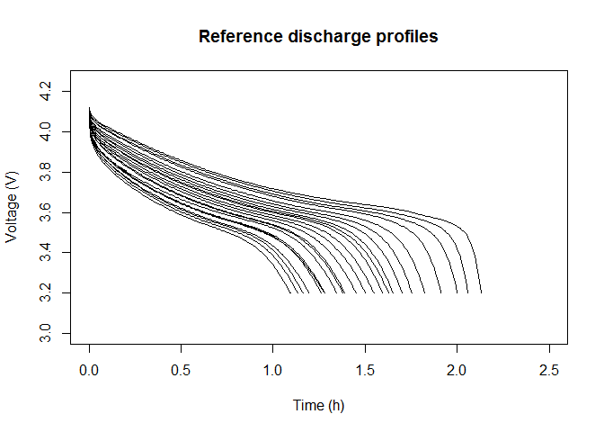

```r
load("data/R/RW13.Rda")  # loading data

# find all of the steps with comment == 'reference discharge'
refDisSteps <- steps[steps$comment %in% 'reference discharge',]

# Initialize Voltage plot
plot(0,0,xlim = c(0,2.5), ylim = c(3,4.25),type="l",
     main = "Reference discharge profiles",
     xlab = "Time (h)",ylab = "Voltage (V)")

# Plot Voltage profiles
for(i in 1:dim(refDisSteps)[1]){
    lines(refDisSteps$relativeTime[[i]]/3600,refDisSteps$voltage[[i]]
          , type="l", lwd=1.5)
}
```

The differences in the voltage profiles observed in the previous plot are due to degradation of battery health over the experiment. As the battery ages, its charge storage capacity decreases, and it’s internal resistance increases.

Here, the battery’s capacity can be benchmarked by integrating current over the reference cycles. The next plot shows this capacity measurement vs date.

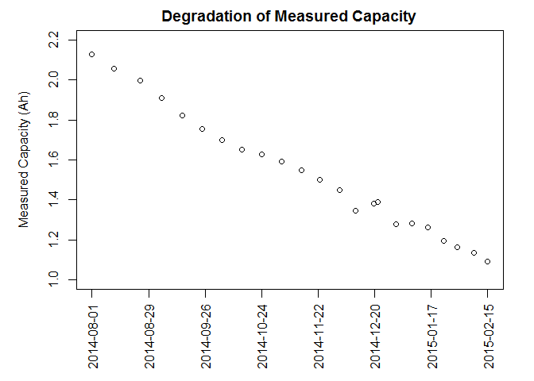

```r
# Library needed for trapezoidal integration
library(caTools)

#Define date format
format <- "%d-%B-%Y %H:%M:%S"

# Identify Reference discharge cycles
refDisSteps <- steps[steps$comment %in% 'reference discharge',]

# Save Date and capacity for Reference discharge cycles
Date <- as.Date(refDisSteps$date,format=format)
Cap <- mapply(trapz,refDisSteps$relativeTime,refDisSteps$current)/3600

# Identify date range for plot
ExpStart<-head(Date,n=1)
ExpEnd<-tail(Date,n=1)

# Initialize plot
par(mar=c(6,5,2,2)) # set plot margins
plot(0,xlim = c(ExpStart,ExpEnd),ylim = c(1,2.2),xaxt="n",
     main = "Degradation of Measured Capacity", xlab='',
     ylab = "Measured Capacity (Ah)")
axis.Date(1, at = seq(ExpStart,ExpEnd,length.out=8),
          labels = seq(ExpStart,ExpEnd,length.out=8),
          format= "%m/%d/%Y", las = 2)

# Plot capacity points
points(Date,Cap, type="p", lwd=1.5)
```

Changes in the battery’s internal resistance can also be observed in these reference discharging profiles by noting how much the battery voltage is pushed down when current is applied and how much it springs back up when no current is applied.

The next code snippet shows how the resting periods after each reference discharge can be grouped with the corresponding reference discharge cycle and added to the plot above.

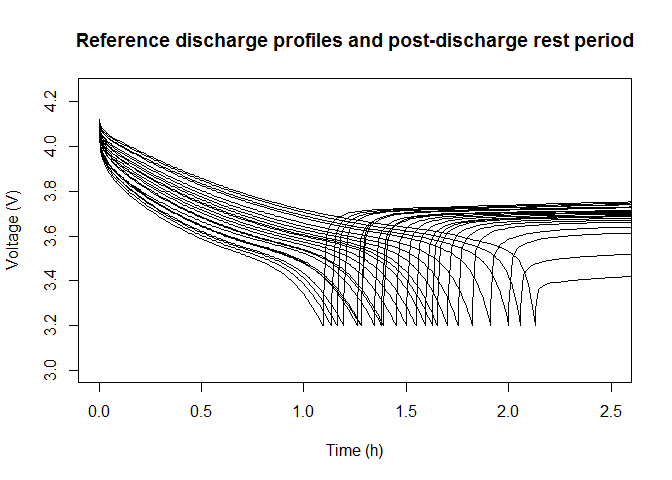

```r
# Identify comment codes of interest
CC <- c("reference discharge", "rest post reference discharge")
# Identify step indexes that match the comment codes
inds <- 1:dim(steps)[1] # set vector of step indexes
indCC <- inds[steps$comment %in% CC]

# identify discontinuities in the indCC array
Breaks <- c(0,which(diff(indCC) != 1),length(indCC))

# separate continuous sequences of indexes into a list
refDisInds<- lapply(seq(length(Breaks)-1),
                function(i) indCC[(Breaks[i]+1):Breaks[i+1]])

# define function that appends the relativeTime columns a sequence of steps into one vector
appendTime <- function(steps){
    # steps is a dataframe including relativeTime and date for a set steps

    Dateformat <- "%d-%B-%Y %H:%M:%S"
    startTime <- strptime(steps$date[[1]], Dateformat)

    TimeCmb <- steps$relativeTime[[1]] # initialize time vector with first relativeTime column

    listLen <- length(steps$relativeTime)
    if(listLen>1){
        for (i in 2:listLen){
            stepTime <- strptime(steps$date[[i]], Dateformat)
            TimeCmb <- c(TimeCmb,difftime(stepTime,startTime,units="secs")+
                             steps$relativeTime[[i]])
        }
    }
    TimeCmb
}

# Initialize plot
plot(0,0,xlim = c(0,2.5), ylim = c(3,4.25),type="l",
     main = "Reference discharge profiles and post-discharge rest period",
     xlab = "Time (h)",ylab = "Voltage (V)")

# Plot profiles
for(i in 1:length(refDisInds)){
    # combine the relativeTime columns in a sequence of steps into one vector
    T<-appendTime(steps[refDisInds[[i]],c("relativeTime","date")])

    # find voltage vector
    V<-unlist(steps[refDisInds[[i]],"voltage"])

    # plot voltage profile
    lines(T/3600,V, type="l", lwd=1.5)
}
```

The differences observed in the resting voltage dynamics shown in these steps are primarily attributed to differences in the battery’s internal resistance as it degrades.

### Example Plots of Reference Power Discharging Cycles

Constant load profiles that are run after every 50 random walk discharge cycles are plotted using.

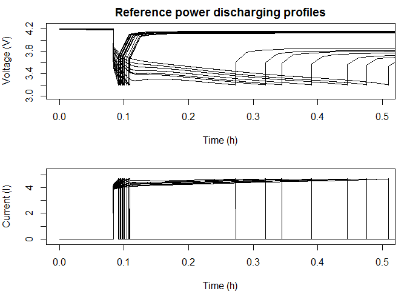

```r
# Identify comment codes of interest
CC <- c("rest post reference charge", "reference power discharge",
        "rest post reference power discharge")

# Identify step indexes that match the comment codes
inds <- 1:dim(steps)[1] # set vector of step indexes
indCC <- inds[steps$comment %in% CC]

# identify discontinuities in the indCC array
Breaks <- c(0,which(diff(indCC) != 1),length(indCC))

# separate continuous sequences of indexes into a list
refDisInds<- lapply(seq(length(Breaks)-1),
                function(i) indCC[(Breaks[i]+1):Breaks[i+1]])

# Create 3 rows of plots
par(mfrow=c(2,1),mar=c(4,4,2,1))

# Initialize Voltage plot
plot(0,0,xlim = c(0,0.5), ylim = c(3,4.25),type="l",
     main = "Reference power discharging profiles",
     xlab = "Time (h)",ylab = "Voltage (V)")

# Plot voltage profiles
for(i in 1:length(refDisInds)){
    # combine the relativeTime columns in a sequence of steps into one vector
    T<-appendTime(steps[refDisInds[[i]],c("relativeTime","date")])

    # find voltage vector
    V<-unlist(steps[refDisInds[[i]],"voltage"])

    # plot voltage profile
    lines(T/3600,V, type="l", lwd=1.5)
}

# Initialize Current plot
plot(0,0,xlim = c(0,0.5), ylim = c(-0.2,5.25), type="l",
     xlab = "Time (h)",ylab = "Current (I)")

# Plot current profiles
for(i in 1:length(refDisInds)){
    # combine the relativeTime columns in a sequence of steps into one vector
    T<-appendTime(steps[refDisInds[[i]],c("relativeTime","date")])

    # find current vector
    I<-unlist(steps[refDisInds[[i]],"current"])

    # plot current profile
    lines(T/3600,I, type="l", lwd=1.5)
}
```

A nonlinear decay in the amount of time the battery can support a 15W is seen in the figure above. The next plot shows the battery capacity as measured from these reference power discharge cycles.

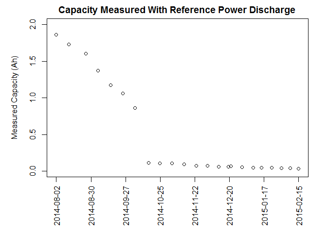

```r
# Identify Reference power discharge cycles

refDisSteps <- steps[steps$comment %in% 'reference power discharge',]

# Save Date and capacity for Reference discharge cycles
Date <- as.Date(refDisSteps$date,format=format)
Cap <- mapply(trapz,refDisSteps$relativeTime,refDisSteps$current)/3600

# Identify date range for plot
ExpStart<-head(Date,n=1)
ExpEnd<-tail(Date,n=1)

# Initialize plot
par(mar=c(6,5,2,2)) # set plot margins
plot(0,xlim = c(ExpStart,ExpEnd),ylim = c(0,2),xaxt="n",
     main = "Capacity Measured With Reference Power Discharge", xlab='',
     ylab = "Measured Capacity (Ah)")
axis.Date(1, at = seq(ExpStart,ExpEnd,length.out=8),
          labels = seq(ExpStart,ExpEnd,length.out=8),
          format= "%m/%d/%Y", las = 2)

# Plot capacity points
points(Date,Cap, type="p", lwd=1.5)
```

### Example Plots of Pulsed Load Discharging Cycles

The pulsed load discharging cycles that are run after every 50 random walk discharging cycles are plotted using.

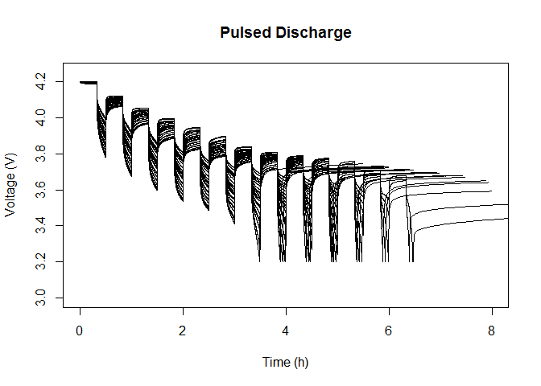

```r
# Identify comment codes of interest for pulsed discharging cycles
CC <- c("pulsed load (rest)", "pulsed load (discharge)", "rest post pulsed load")

# Identify step indexes that match the comment codes
inds <- 1:dim(steps)[1] # set vector of step indexes
indCC <- inds[steps$comment %in% CC]

# identify discontinuities in the indCC array
Breaks <- c(0,which(diff(indCC) != 1),length(indCC))

# separate continuous sequences of indexes into a list
refInds<- lapply(seq(length(Breaks)-1),
                function(i) indCC[(Breaks[i]+1):Breaks[i+1]])

# Delete the resting steps that do not get grouped
refInds<-refInds[sapply(refInds,function(x) length(x)>1)]

# Initialize plot
plot(0,0,xlim = c(0,8), ylim = c(3,4.25),type="l",
     main = "Pulsed Discharge",
     xlab = "Time (h)",ylab = "Voltage (V)")

# Plot profiles
for(i in 1:length(refInds)){
    # combine the relativeTime columns in a sequence of steps into one vector
    T<-appendTime(steps[refInds[[i]],c("relativeTime","date")])

    # find voltage vector
    V<-unlist(steps[refInds[[i]],"voltage"])

    # plot voltage profile
    lines(T/3600,V, type="l", lwd=1.5)
}
```

## Looking at the Randomized Discharging Data

The RW discharging profiles are composed of 1 minute periods of discharging the batteries at a particular current, with interleaved periods of resting the battery (current = 0).

The following sample code shows data collected over the first 10 and the last 10 RW discharge cycles in the experiment.

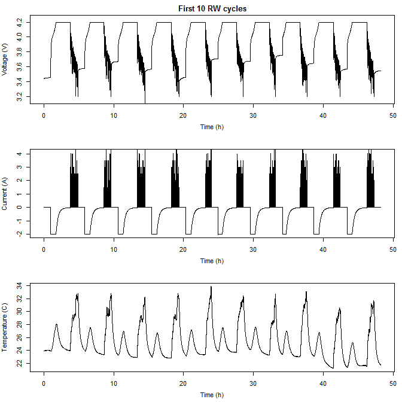

```r
# Identify comment codes of interest
CC <- c("discharge (random walk)", "rest (random walk)", "rest post random walk discharge")

# Identify step indexes that match the comment codes
inds <- 1:dim(steps)[1] # set vector of step indexes
indCC <- inds[steps$comment %in% CC]

# identify discontinuities in the indCC array
Breaks <- c(0,which(diff(indCC) != 1),length(indCC))

# Plot all voltage, current, and temperature data recorded for first 10 RW discharge cycles
# Create 3 rows of plots
par(mfrow=c(3,1),mar=c(4,4,2,1))

# identify index sequence for first 10 RW discharge cycles
inds <- head(indCC[[Breaks[1]+1]],n=1):tail(indCC[[Breaks[12]]],n=1)

# combine the relativeTime columns in a sequence of steps into one vector
T<-appendTime(steps[inds,c("relativeTime","date")])

# divide by 3600 to convert from seconds to hours
T<- T/3600

# find voltage vector
V<-unlist(steps[inds,"voltage"])

# find current vector
I<-unlist(steps[inds,"current"])

# find temperature vector
Tp<-unlist(steps[inds,"temperature"])

# plot voltage
plot(T,V, ylim = c(3.15,4.25),type="l",
       main = "First 10 RW cycles", xlab = "",
       ylab = "Voltage (V)")
  title(xlab = "Time (h)", line = 2.5)

# plot current
plot(T,I, ylim = c(-2,4.1),type="l",
     xlab = "",ylab = "Current (A)")
  title(xlab = "Time (h)", line = 2.5)

# plot temperature
plot(T,Tp, type="l",
     xlab = "",ylab = "Temperature (C)")
  title(xlab = "Time (h)", line = 2.5)
```

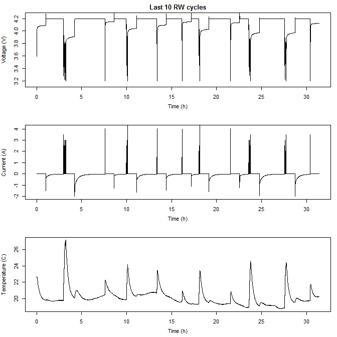

```r
# Plot all voltage, current, and temperature data recorded for last 10 RW discharge cycles

# identify index sequence for last 10 RW discharge cycles
n<-length(Breaks)
inds <- head(indCC[[Breaks[n-10]]],n=1):tail(indCC[[Breaks[n]]],n=1)

# combine the relativeTime columns in a sequence of steps into one vector
T<-appendTime(steps[inds,c("relativeTime","date")])

# divide by 3600 to convert from seconds to hours
T<- T/3600

# find voltage vector
V<-unlist(steps[inds,"voltage"])

# find current vector
I<-unlist(steps[inds,"current"])

# find temperature vector
Tp<-unlist(steps[inds,"temperature"])

# plot voltage
plot(T,V, ylim = c(3.15,4.25),type="l",
       main = "Last 10 RW cycles", xlab = "",
       ylab = "Voltage (V)")
  title(xlab = "Time (h)", line = 2.5)

  # plot current
plot(T,I, ylim = c(-2,4.1),type="l",
     xlab = "",ylab = "Current (A)")
  title(xlab = "Time (h)", line = 2.5)

# plot temperature
plot(T,Tp, type="l",
     xlab = "",ylab = "Temperature (C)")
  title(xlab = "Time (h)", line = 2.5)
```

The duration of RW discharging periods is seen to be shorter for the last 10 RW discharging cycles than is seen in the first 10 cycles. This is due to the degradation of battery health over the experiment, which results in decreased charge storage capacity, and increased internal resistance.